# Temporal disease progress: Linear and non-linear regression models

### **Visualize predicted versus observed values**

We’ll transform our data structure to be long, just as we did in the Linear section. This will make it easy to plot each model’s values in a different color.

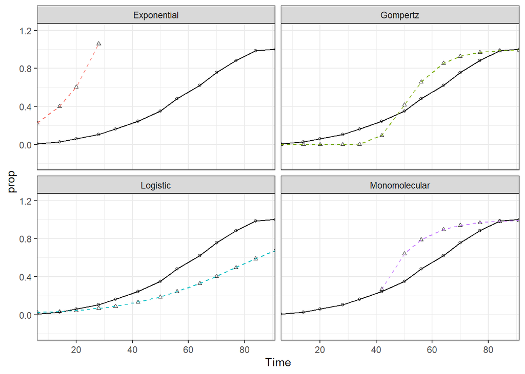

```r
# Create a vector including all column names except dai and prop
vars_to_long <- colnames(dta)[!colnames(dta) %in% c("dai", "prop")]

# Create dta_long by
dta_long <-
dta %>%

    # Concating the values in those columns
    pivot_longer(cols = vars_to_long,

                 # Putting the column names in column 'origin'
                 names_to = "origin",

                 # And putting their values in 'fits'
                 values_to = "fits"
    )

# Take dta_long and plot it
# Challenge: Can you interpret what each line means? Use a # to leave an explanation above each line.
dta_long %>%
ggplot()+
  geom_point(aes(dai, prop),size = 1, shape = 1) +
  geom_line(aes(dai, prop),linetype = "solid")+
  geom_point(aes(dai, fits),size = 1, shape = 2) +
  geom_line(aes(dai, fits, color = origin),linetype = "dashed")+

  theme_bw()+
  scale_y_continuous(limits = c(0, 1),
                     expand = c(c(-.05, 1.05)),
                     breaks = seq(0, 1, 0.2),
                     name = "Disease") +
  scale_x_continuous(expand = c(0, 0),
                     breaks = seq(0, 80, 20),
                     name = "Time")+
  facet_wrap(~origin, ncol = 2)+
  ylim(-0.2,1.2) +
  theme(legend.position = "none")
```

**Questions**:

> Where does each model fit the data best? Why? Where is the fit the poorest for each model? Why?

# **Nonlinear regression**

Nonlinear regression is necessary when the relationship between the independent and response variable(s) is non-linear. This can occur simply because the relationship between the response variable and a single independent variable is nonlinear. It can also occur when multiple variables, each with a linear relationship to the response variable, have an overall relationship that can’t be expressed as linear.

Nonlinear regression can be tricky because there isn’t a closed-form expression to describe the parameters. While simple linear regression can be expressed in some form of the below formula, nonlinear models cannot.

Linear model:
$$Y_i = \beta_0 + \beta_1 X_i + \epsilon_i$$
Because of this, it can be hard to define important parameters necessary to create a model.

In these cases, we can use functions like `nls()` or Nonlinear Least Squares, from base R. Fundamentally, we are creating and evaluating an assortment of models, using different parameters until we find the best one. The idea is that we don’t transform the data so that we are not bound by more assumptions.

There are different methods to define initial starting parameters:

> Method 1: Use a grid search approach to find the best combination of all parameters

> Method 2: Do a preliminary analysis to estimate parameters. This preliminary analysis can be performed on data similar to your situation.

> Method 3: Estimating parameters based on what is known about the system.

> Method 4: Using a genetic algorithm. Learn more about genetic algorithms here: https://en.wikipedia.org/wiki/Genetic_algorithm

> Method 5: Use one of a variety of R functions, like nls(), to test multiple models until convergence (agreement) between the best of them is reached.

### **Fit models**

We’ll use `nls()` to create a function that tests formulas against our test data, starting with parameters y0 = 0.001 and r = 0.05. Starting with minimum start values can save you computational time by not running models that can’t fit. Because trace = TRUE, the model will be estimated iteratively, and its fit will be evaluated with the example data.

```r
# Name the function and its required inputs
FitMod <-function(mod, data){

  # Define the operation of the function and which input goes where
    nls(mod,
      start = list(y0 = 0.001, rate = 0.05),
      trace = TRUE,
      data = dta)
}
```

Define formulas to test with `FitMod()`.

```r
# Define formulas
exp_formula <-  formula(prop ~ y0 * exp(rate*dai))
log_formula <-  formula(prop ~ 1/(1+exp(-(log(y0/(1-y0))+rate*dai))))
gom_formula <-  formula(prop ~ exp(log(y0)*exp(-rate*dai)))
mon_formula <-  formula(prop ~ 1-((1-y0)*exp(-rate*dai)))
```

Run `FitMod()` with each of the formulas.

```r
# Use the defined formulas as the mod input to FitMod()
exp_mod <-  FitMod(exp_formula, dta)
log_mod <-  FitMod(log_formula, dta)
gom_mod <-  FitMod(gom_formula, dta)
mon_mod <-  FitMod(mon_formula, dta)
```

We can use `minpack.lm::nlsLM()` to explore further modifications of the Levenberg-Marquardt algorithm, the algorithm used for nonlinear least squares, with the Gompertz model. With this function, you can define upper and lower boundaries, again reducing the computational time necessary by eliminating possible models. We use the `control` argument to determine the number of iterations.

```r
# Create gom_mod with the Gompertz formula inside function nlsLM()
gom_mod <-
minpack.lm::nlsLM(prop ~ exp(log(y0)*exp(-rate*dai)),
      start=list(y0=0.001, rate=0.05),
      control = list(maxiter = 2000, maxfev = 5000),
      upper = c(.2, .2),
      lower = c(1e-8, .0001),
      data = dta)
```

Similar to the linear modeling exercise, model fits can be saved into a list. Each element of the list is named according to the population growth model used.

```r
# Create list 'models' with mon_mon, exp_mod, etc. as elements
models <- list(mon_mod, exp_mod, log_mod, gom_mod)

# Name the elements of the list appropriately
names(models) <-  c("Monomolecular", "Exponential", "Logistic", "Gompertz")
```

We can estimate the goodness of fit of the resulting models with the **pseudo R<sup>2</sup>** value. This is an estimate of the R<sup>2</sup> value we’ve seen before. Since it isn’t possible to calculate a single R<sup>2</sup> value, we use the approximation instead to determine goodness of fit instead.

We will write a function to calculate it.

```r
# In function PseudoRsq, you input model and disease
PseudoRsq <- function(model, disease) {

  # You calculate the R2/sum of the residuals squared of the linear model
  RSS.1 <- sum(residuals(model)^2)

  # The R2 of the observed vs. predicted disease
  TSS.1 <- sum((disease - mean(disease))^2)

  # And subtract that proportion from 1
  (1 - (RSS.1 / TSS.1))
}
```

Now we’ll calculate the expected values for each model, as well as a pseudo R<sup>2</sup>.

```r
# Create a dataframe with columns 'models' and 'r_sq' to save the pseudo R^2 results to.
fit_diag <- data.frame(models = names(models), r_sq = rep(NA, length(models)))

# For each model
for(i in seq(models)){

  # Make a variable with the model name
  model_name <- names(models[i])

  # Calculate predictions for that model and save them in a new column
  dta[, model_name] <-
    predict(object= models[[i]],
            newdata=dta[, "dai"])

  fit_diag[ fit_diag$models == model_name, "r_sq"] <-
    PseudoRsq(models[[i]], dta$prop)

}

# Show the first five predicted values for each model
gt::gt(head(dta, 5)) # Show the first five rows
```

[output not shown]

```r
# Show the pseudo R^2 value for each model.
gt::gt(fit_diag)
```

| models | r_sq |
| --- | --- |
| Monomolecular | -20.8543557 |
| Exponential | -0.9801843 |
| Logistic | -13.9534920 |
| Gompertz | 0.9770406 |

This code is very similar to the previous one presented earlier. The only major difference is that the model fit diagnostics are joined to the data and plotted as a text label.

### **Visualize fits**

Now we will visualize the fit of each of our nonlinear models. Just like the previous two times, we need to transform our data structure.

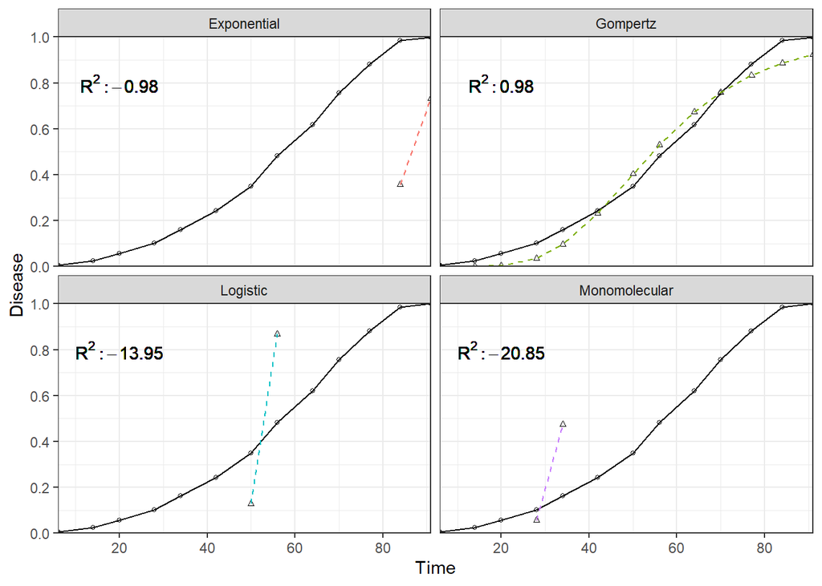

```r
# Create a vector of columns to remove
vars_to_long <- colnames(dta)[!colnames(dta) %in% c("dai", "prop")]

# Create dta_long by taking dta and
dta_long <-
dta %>%

    # Concatenating the values from columns we don't want
    pivot_longer(cols = vars_to_long,

                 # Putting the column names in column 'models' as values
                 names_to = "models",

                 # And putting the values in column 'fits
                 values_to = "fits"
    ) %>%
  # and joining it to the model_diag (the object with model names and pseudo R^2 values)
  left_join(., fit_diag, by = "models")

# Take dta_long
 dta_long %>%

   # Plot it
ggplot()+
  geom_point(aes(dai, prop),size = 1, shape = 1) +
  geom_line(aes(dai, prop),linetype = "solid")+
  geom_point(aes(dai, fits),size = 1, shape = 2) +
  geom_line(aes(dai, fits, color = models),linetype = "dashed")+
  # Add labels for model fit diag.
  geom_text(aes( label = paste("R^2: ", round(r_sq,2),sep="")),parse=T,x=20,y=.8)+
  theme_bw()+
  facet_wrap(~models, ncol = 2)+
  scale_y_continuous(limits = c(0, 1),
                     expand = c(0, 0),
                     breaks = seq(0, 1, 0.2),
                     name = "Disease") +
  scale_x_continuous(expand = c(0, 0),
                     breaks = seq(0, 80, 20),
                     name = "Time")+
  theme(legend.position = "none")
```

Now we’ve seen several additional ways to model disease progression and discussed their suitability. Additionally, we have learned valuable R tools such as if else statements that can help us manipulate data.